# Mushroom Classification Project

```python
# Import the necessary libraries
import numpy as np # linear algebra
import pandas as pd # data processing, CSV file I/O (e.g. pd.read_csv)
import os
import seaborn as sns
import matplotlib as mpl
import matplotlib.pyplot as plt
from sklearn.preprocessing import LabelEncoder
from sklearn.model_selection import train_test_split
from sklearn.model_selection import cross_val_score
from sklearn import tree
from sklearn.model_selection import GridSearchCV
from sklearn.tree import DecisionTreeClassifier
from sklearn.tree import export_graphviz
import graphviz
from sklearn.tree import plot_tree
import matplotlib.pyplot as plt
```

```python
# Load the mushroom dataset
df = pd.read_csv('Mushroom Assignment Data_ed-1.csv')
```

## Data Exploration

We begin by loading the mushroom dataset, which consists of 8,124 samples and 24 features. The target variable is the class of the mushrooms, with two categories: poisonous and edible. We examine the distribution of classes and find that the dataset is balanced, with 4,208 edible mushrooms and 3,916 poisonous mushrooms.

Next, we transform the categorical features into numerical values using label encoding. This ensures that the data can be used effectively by machine learning algorithms.

```python
# Examining the Data
df.shape
```

```
(8124, 24)
```

```python
df['classes'].unique()
```

```
array(['poisonous', 'edible'], dtype=object)
```

```python
df['classes'].value_counts()
```

```
edible       4208
poisonous    3916
Name: classes, dtype: int64
```

## Exploratory Data Analysis

To understand the dataset further, we visualize the number of poisonous and edible mushrooms using a bar plot. This plot provides a clear representation of the class distribution in the dataset.

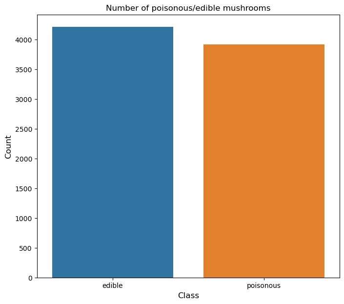

```python
count = df['classes'].value_counts()
plt.figure(figsize=(8,7))
sns.barplot(x=count.index, y=count.values)
plt.ylabel('Count', fontsize=12)
plt.xlabel('Class', fontsize=12)
plt.title('Number of poisonous/edible mushrooms')
plt.show()
```

```python
df = df.astype('category')
df.dtypes
```

```
ID                          category
cap_shape                   category
cap_surface                 category
cap_color                   category
bruises                     category
odor                        category
gill_attachment             category
gill_spacing                category
gill_size                   category
gill_color                  category
stalk_shape                 category
stalk_root                  category
stack_surface_above_ring    category
stack_surface_below_ring    category
stack_color_above_ring      category
stack_color_below_ring      category
veil_type                   category
veil_color                  category
ring_number                 category
ring_type                   category
spore_print_color           category
population                  category
habitat                     category
classes                     category
dtype: object
```

```python
labelencoder=LabelEncoder()
for column in df.columns:
    df[column] = labelencoder.fit_transform(df[column])
```

Additionally, we create a correlation matrix heatmap to explore the relationships between different features. The heatmap displays the correlation coefficients, ranging from -1 to 1, where values closer to 1 indicate a strong positive correlation and values closer to -1 indicate a strong negative correlation. This visualization helps us identify variables that are strongly related to each other.

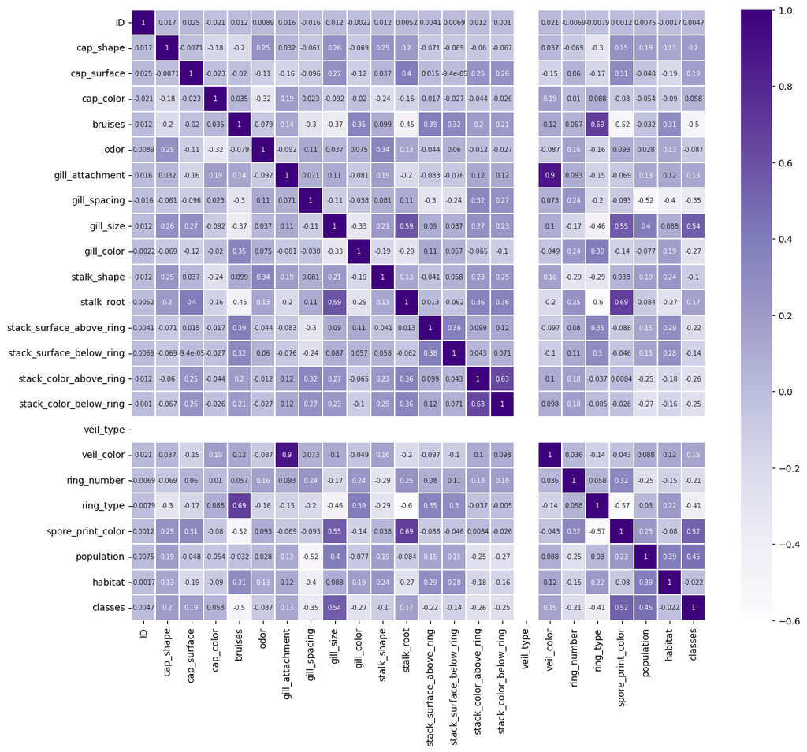

```python
plt.figure(figsize=(14,12))
sns.heatmap(df.corr(),linewidths=.1,cmap="Purples", annot=True, annot_kws={"size": 7})
plt.yticks(rotation=0);
```

Furthermore, we investigate the relationship between mushroom odor, bruises, and edibility. By creating a categorical plot, we can observe the counts of mushrooms with different odors and bruises, grouped by their edibility. This analysis provides insights into how these factors contribute to the classification of mushrooms as poisonous or edible.

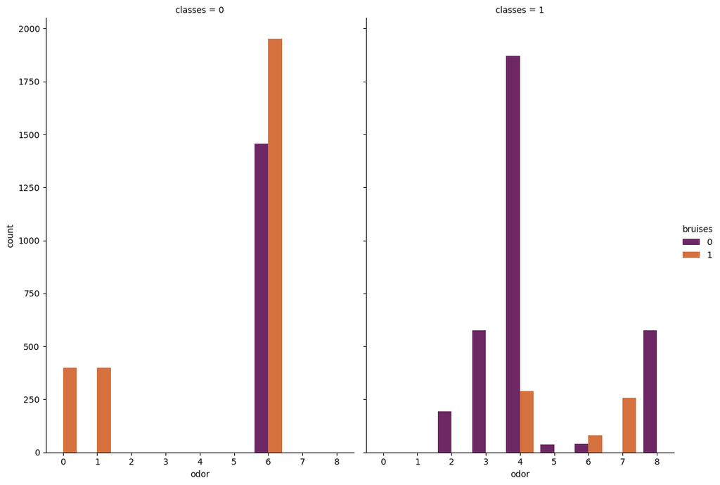

```python
plt.figure(figsize = (14,6))
g = sns.catplot(x="odor", hue="bruises", col="classes",
                data=df, kind="count",
                height=8, aspect=.7 , palette = 'inferno');
```

```python
df[['classes', 'odor']].groupby(['odor'], as_index=False).mean().sort_values(by='classes', ascending=False)
```

|  | odor | classes |
| --- | --- | --- |
| 2 | 2 | 1.000000 |
| 3 | 3 | 1.000000 |
| 4 | 4 | 1.000000 |
| 5 | 5 | 1.000000 |
| 7 | 7 | 1.000000 |
| 8 | 8 | 1.000000 |
| 6 | 6 | 0.034014 |
| 0 | 0 | 0.000000 |
| 1 | 1 | 0.000000 |

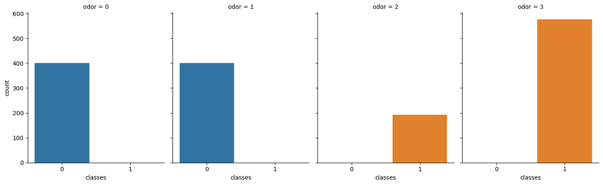

```python
new_var = df[['classes', 'odor']]
new_var = new_var[new_var['odor']<=3.5]
sns.catplot(x='classes', col='odor', data=new_var, kind='count', height=4.5, aspect=.8, col_wrap=4)
```

## Decision Tree Model

To build a predictive model, we split the dataset into training and testing sets. We employ a decision tree classifier and train it on the training set. The decision tree model learns the patterns and relationships within the features to make predictions about the class of mushrooms.

```python
X = df.drop(['classes'], axis=1)
y = df['classes']
X_train, X_test, y_train, y_test = train_test_split(X, y, random_state=42, test_size=0.1)
```

```python
dt = DecisionTreeClassifier()
dt.fit(X_train, y_train)
```

```
DecisionTreeClassifier()
```

Finally, we visualize the decision tree, which illustrates the decision-making process of the model. Each node in the tree represents a decision based on one of the features, with the branches indicating the possible outcomes. This visualization provides a clear understanding of how the model uses the features to classify mushrooms.

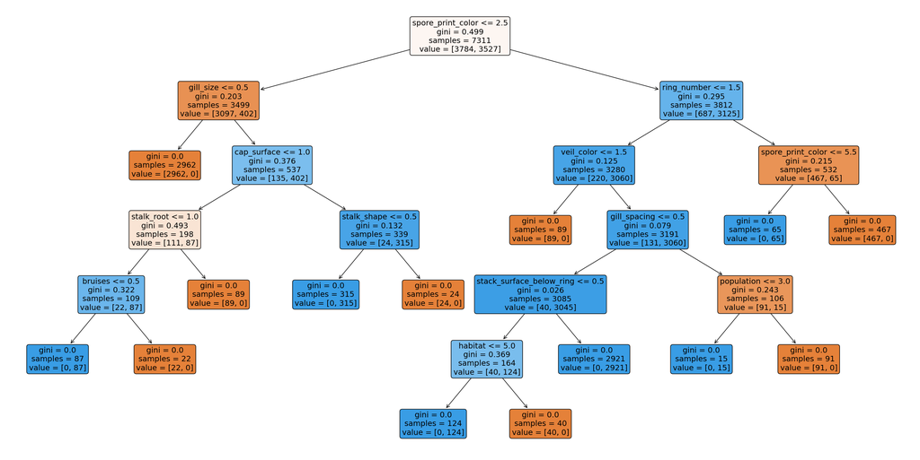

```python
plt.figure(figsize=(30, 15))
plot_tree(dt, feature_names=X.columns, filled=True, rounded=True, fontsize=14)
plt.show()
```